# Intel Student Developer Club, RCOEM

## Machine Learning Bootcamp, 2022

## Day - 1 : Introduction to Machine Learning 👋

### Machine Learning →

Machine learning has become one of the most important topics within development organizations that are looking for innovative ways to leverage data assets to help their business gain a new level of understanding.

> Machine learning is a form of AI that enables a system to learn from data rather than through explicit programming.

> ~Arthur Samuel (1959)

Like this, there are various other definitions of machine learning according to different researchers, scientists and authors.

> A computer program is said to learn from experience E with respect to some task T and some performance measure P, if its performance on T, as measured by P, improves with experience E.

> ~ Tom Mitchell (1998)

> Machine Learning is about extracting knowledge from data.

> ~ Andreas Mueller (2012)

[figure not shown]

### Daily Use Cases of Machine Learning Algorithms :-

- Web search results are ranked using ML algorithms.
- Facebook’s face recognition also works on machine learning models.
- ML also helps in distinguishing between spam and non-spam emails.

> The main agenda of machine learning is to develop algorithms that mimic near human neural networks / mimic how the human brain 🧠 works.

#### Artificial Intelligence vs. Machine Learning

| **Artificial Intelligence** | **Machine Learning** |
| --- | --- |
| Artificial Intelligence is a technology which enables a machine to simulate human behavior | Machine Learning is a subset of AI which allows a machine to 'learn' from past data without programming explicitly. |
| The goal of AI is to make a smart computer system like humans to solve complex problems | The goal of ML is to allow machines to learn from data so that they can give accurate predictions. |
| AI is working to create an intelligent system which can perform various complex tasks. | Machine Learning is working to create machines that can perform only those specific tasks for which they are trained. |

### History of ML :

Manually crafting decision rules is feasible for some applications, particularly for those in which humans have good understanding of the process to model. For example, "**spam filtering**"; in the early days of computing companies used to use hardcoded `if - else` conditions / decisions to mark an email as spam. It used to read the mail line by line and used to look for words like `sale, offers, apply now, buy now` etc., hard-coding this scenario was easy as it is human friendly.

`if - else` condition creates a decision tree model, and the algorithm computes the result based on those decisions.

Consider a situation; you are thinking of buying a house and for that you compare lots and lots of properties, from which you infer that houses with 3 bedrooms are more expensive than a house with 2 bedrooms (well, duh!). But, there is one more thing you infer, for a property in your local area average price of a 3 BHK house is $30,000 and that of a 2 BHK is $20,000. Now let us create a decision tree based on this data.

[figure not shown]

```
if num_bedrooms() > 2:
    projected_price = 30,000
else :
    projected_price = 20,000
```

The step of capturing patterns from data is called fitting or training of a model, and the data used to fit the model is called the training data The above figure is a machine learning model in its rawest form.

Let's now upgrade our model by introducing a new feature and some new data, consider another pattern that deals with the size of the property

[figure not shown]

### Types of Machine Learning Models :

1. *Supervised Model* : In this type of model data points have known outcome.
2. *Unsupervised Model* : In this type of model data points have unknown outcome.

Further, there are two types of actions performed by supervised models :

1. *Classification* : In which the outcome is categorical (non-continuous)
2. *Regression* : In which the outcome is numerical (continuous)

### Supervised Learning :

- One of the most commonly used and successful type of ML.
- Used whenever we want to predict a certain outcome from a given input which is new and unknown to the model.
- Our goal is to make accurate predictions, for newer, never before seen data.

⚠️ Often requires human efforts to build the training set.

[figure not shown]

#### A. Classification

→ Goal is to predict a class label, which is a choice from a predefined list of possibilities.  
Ex. Predicting the breed of a dog given its leg height, tail height, weight etc.

#### A. Regression

→ Goal is to predict a continuous number, or a floating point / real number.  
Ex. Predicting a person's salary given his/her age, occupation, experience, education etc.

### Machine Learning Vocabulary :

[figure not shown]

#### What is a model?

The above data has various values that corresponds to a specific target;

$\alpha$ sepal_length + $\beta$ sepal_width + $\gamma$ petal_length + $\delta$ petal_width = Label

Training a model is nothing more than finding the values of $\alpha$, $\beta$, $\gamma$ and $\delta$, then for any never-before seen value of features we can predict the label of the data.

### Our Very First Machine Learning Model :

#### K - Nearest Neighbors (KNN) :

- In this model we take a new point whose labels are to be predicted and look for its nearest neighbors, `k` here is the number of neighbors we want to compare the new data point with. For ex, if there are data points which corresponds to two different classes then the new data point will correspond to the class which are more in number in the vicinity of the random point.
- We compare the new data point's distance from other points using the `Euclidian Distance Formula`; $d = \sqrt{(x_2 - x_1)^2 + (y_2 - y_1)^2}$

[figure not shown]

> ℹ️ A data point is classified by majority votes from its `k` nearest neighbors.

#### How to choose the value of k?

→ KNN is based on *feature similarity*, choosing the right values of `k` is a process called parameter tuning, and is important for better performance.

- If `k` is low, we can get skewed answers (if the data points are noisy, ie., there is no perfect cluster).
- If `k` is very large, then more number of calculations will be required to find nearest points.

Probable values of `k` can be :-

- $\sqrt{n}$, where $n$ is the number of data points.
- Any respectable odd value, to avoid conflict or to break ties. If `k` = 2 and one neighbour is blue and other is orange, then new value can be anything. (Back to square 1!)

> Decision boundary is the line between where the algorithm will assign class 0 vs class 1.

> When we train the model for a particular value of `k` we are basically tracing out the decision boundary. It changes for different values of `k`.

[figure not shown]

### Characteristics of KNN :

- Fast to create models as it simply stores the data.
- Slow to predict because many computations to find distance.
- Can require lots of memory if data is large.

### KNN Summarised :

- A positive integer (preferably odd) is specified, along with a new sample.
- We select the `k` entries in our database which are closest to the new sample.
- We find the most common classification of these entries [Voting]
- This classification is given to the new sample.

## Enough Theory, Hands-on Time!

### Step 1 :

→ Importing the required libraries and data

```python
import numpy as np
import pandas as pd
import matplotlib.pyplot as plt
import seaborn as sns

from sklearn.datasets import load_iris  # Importing our dataset to create model
```

### Step 2:

→ Exploring the Data

```python
iris = load_iris()  # Creating an object of the dataset

iris
```

[output not shown]

[output cut: 110 more lines]

[output not shown]

```python
iris.DESCR  # We can get all the information about our dataset using this method
```

```
'.. _iris_dataset:\n\nIris plants dataset\n--------------------\n\n**Data Set Characteristics:**\n\n    :Number of Instances: 150 (50 in each of three classes)\n    :Number of Attributes: 4 numeric, predictive attributes and the class\n    :Attribute Information:\n        - sepal length in cm\n     …
```

```python
iris.feature_names  # Features / columns of the dataset
```

```
['sepal length (cm)',
 'sepal width (cm)',
 'petal length (cm)',
 'petal width (cm)']
```

```python
iris.target_names   # Target / label values of the dataset
```

```
array(['setosa', 'versicolor', 'virginica'], dtype='<U10')
```

```python
# <U10 -> 10 character unicode string
```

```python
iris.data   # All the column values of our dataset in the form of a 2D list
```

```
array([[5.1, 3.5, 1.4, 0.2],
       [4.9, 3. , 1.4, 0.2],
       [4.7, 3.2, 1.3, 0.2],
       [4.6, 3.1, 1.5, 0.2],
       [5. , 3.6, 1.4, 0.2],
       [5.4, 3.9, 1.7, 0.4],
       [4.6, 3.4, 1.4, 0.3],
       [5. , 3.4, 1.5, 0.2],
       [4.4, 2.9, 1.4, 0.2],
       [4.9, 3.1, 1.5, 0.1],
       [5.4, 3.7, 1.5, 0.2],
       [4.8, 3.4, 1.6, 0.2],
       [4.8, 3. , 1.4, 0.1],
       [4.3, 3. , 1.1, 0.1],
       [5.8, 4. , 1.2, 0.2],
       [5.7, 4.4, 1.5, 0.4],
       [5.4, 3.9, 1.3, 0.4],
       [5.1, 3.5, 1.4, 0.3],
       [5.7, 3.8, 1.7, 0.3],
       [5.1, 3.8, 1.5, 0.3],
       [5.4, 3.4, 1.7, 0.2],
       [5.1, 3.7, 1.5, 0.4],
       [4.6, 3.6, 1. , 0.2],
       [5.1, 3.3, 1.7, 0.5],
       [4.8, 3.4, 1.9, 0.2],
       [5. , 3. , 1.6, 0.2],
       [5. , 3.4, 1.6, 0.4],
       [5.2, 3.5, 1.5, 0.2],
       [5.2, 3.4, 1.4, 0.2],
       [4.7, 3.2, 1.6, 0.2],
       [4.8, 3.1, 1.6, 0.2],
       [5.4, 3.4, 1.5, 0.4],
       [5.2, 4.1, 1.5, 0.1],
       [5.5, 4.2, 1.4, 0.2],
       [4.9, 3.1, 1.5, 0.2],
       [5. , 3.2, 1.2, 0.2],
       [5.5, 3.5, 1.3, 0.2],
       [4.9, 3.6, 1.4, 0.1],
       [4.4, 3. , 1.3, 0.2],
       [5.1, 3.4, 1.5, 0.2],
```

[output cut: 95 more lines]

```
       [7.7, 3. , 6.1, 2.3],
       [6.3, 3.4, 5.6, 2.4],
       [6.4, 3.1, 5.5, 1.8],
       [6. , 3. , 4.8, 1.8],
       [6.9, 3.1, 5.4, 2.1],
       [6.7, 3.1, 5.6, 2.4],
       [6.9, 3.1, 5.1, 2.3],
       [5.8, 2.7, 5.1, 1.9],
       [6.8, 3.2, 5.9, 2.3],
       [6.7, 3.3, 5.7, 2.5],
       [6.7, 3. , 5.2, 2.3],
       [6.3, 2.5, 5. , 1.9],
       [6.5, 3. , 5.2, 2. ],
       [6.2, 3.4, 5.4, 2.3],
       [5.9, 3. , 5.1, 1.8]])
```

```python
iris_df = pd.DataFrame(iris.data, columns=iris.feature_names)

iris_df     # Creating a dataframe from the given raw data
```

|  | sepal length (cm) | sepal width (cm) | petal length (cm) | petal width (cm) |
| --- | --- | --- | --- | --- |
| 0 | 5.1 | 3.5 | 1.4 | 0.2 |
| 1 | 4.9 | 3.0 | 1.4 | 0.2 |
| 2 | 4.7 | 3.2 | 1.3 | 0.2 |
| 3 | 4.6 | 3.1 | 1.5 | 0.2 |
| 4 | 5.0 | 3.6 | 1.4 | 0.2 |
| ... | ... | ... | ... | ... |
| 145 | 6.7 | 3.0 | 5.2 | 2.3 |
| 146 | 6.3 | 2.5 | 5.0 | 1.9 |
| 147 | 6.5 | 3.0 | 5.2 | 2.0 |
| 148 | 6.2 | 3.4 | 5.4 | 2.3 |
| 149 | 5.9 | 3.0 | 5.1 | 1.8 |

150 rows × 4 columns

```python
iris_df['species'] = pd.DataFrame(iris.target)  # Creating a column that will contain the target values of all the entries

iris_df
```

|  | sepal length (cm) | sepal width (cm) | petal length (cm) | petal width (cm) | species |
| --- | --- | --- | --- | --- | --- |
| 0 | 5.1 | 3.5 | 1.4 | 0.2 | 0 |
| 1 | 4.9 | 3.0 | 1.4 | 0.2 | 0 |
| 2 | 4.7 | 3.2 | 1.3 | 0.2 | 0 |
| 3 | 4.6 | 3.1 | 1.5 | 0.2 | 0 |
| 4 | 5.0 | 3.6 | 1.4 | 0.2 | 0 |
| ... | ... | ... | ... | ... | ... |
| 145 | 6.7 | 3.0 | 5.2 | 2.3 | 2 |
| 146 | 6.3 | 2.5 | 5.0 | 1.9 | 2 |
| 147 | 6.5 | 3.0 | 5.2 | 2.0 | 2 |
| 148 | 6.2 | 3.4 | 5.4 | 2.3 | 2 |
| 149 | 5.9 | 3.0 | 5.1 | 1.8 | 2 |

150 rows × 5 columns

```python
iris_df['flower name'] = iris_df.species.apply(lambda x: iris.target_names[x])  # giving names according to the target value

# 0 -> Iris - Setosa
# 1 -> Iris - Versicolor
# 2 -> Iris - Virginica

iris_df
```

|  | sepal length (cm) | sepal width (cm) | petal length (cm) | petal width (cm) | species | flower name |
| --- | --- | --- | --- | --- | --- | --- |
| 0 | 5.1 | 3.5 | 1.4 | 0.2 | 0 | setosa |
| 1 | 4.9 | 3.0 | 1.4 | 0.2 | 0 | setosa |
| 2 | 4.7 | 3.2 | 1.3 | 0.2 | 0 | setosa |
| 3 | 4.6 | 3.1 | 1.5 | 0.2 | 0 | setosa |
| 4 | 5.0 | 3.6 | 1.4 | 0.2 | 0 | setosa |
| ... | ... | ... | ... | ... | ... | ... |
| 145 | 6.7 | 3.0 | 5.2 | 2.3 | 2 | virginica |
| 146 | 6.3 | 2.5 | 5.0 | 1.9 | 2 | virginica |
| 147 | 6.5 | 3.0 | 5.2 | 2.0 | 2 | virginica |
| 148 | 6.2 | 3.4 | 5.4 | 2.3 | 2 | virginica |
| 149 | 5.9 | 3.0 | 5.1 | 1.8 | 2 | virginica |

150 rows × 6 columns

```python
iris_df.index = pd.Series(range(1, 151))    # changing index values for dataframe

iris_df
```

|  | sepal length (cm) | sepal width (cm) | petal length (cm) | petal width (cm) | species | flower name |
| --- | --- | --- | --- | --- | --- | --- |
| 1 | 5.1 | 3.5 | 1.4 | 0.2 | 0 | setosa |
| 2 | 4.9 | 3.0 | 1.4 | 0.2 | 0 | setosa |
| 3 | 4.7 | 3.2 | 1.3 | 0.2 | 0 | setosa |
| 4 | 4.6 | 3.1 | 1.5 | 0.2 | 0 | setosa |
| 5 | 5.0 | 3.6 | 1.4 | 0.2 | 0 | setosa |
| ... | ... | ... | ... | ... | ... | ... |
| 146 | 6.7 | 3.0 | 5.2 | 2.3 | 2 | virginica |
| 147 | 6.3 | 2.5 | 5.0 | 1.9 | 2 | virginica |
| 148 | 6.5 | 3.0 | 5.2 | 2.0 | 2 | virginica |
| 149 | 6.2 | 3.4 | 5.4 | 2.3 | 2 | virginica |
| 150 | 5.9 | 3.0 | 5.1 | 1.8 | 2 | virginica |

150 rows × 6 columns

Now that we have analysed the data and converted it into a dataframe to make it user-friendly, we can now try to visualize this data.

```python
sns.set_style('darkgrid')
colors = ['#003f5c', '#58508d', '#bc5090', '#ff6361', '#ffa600']
```

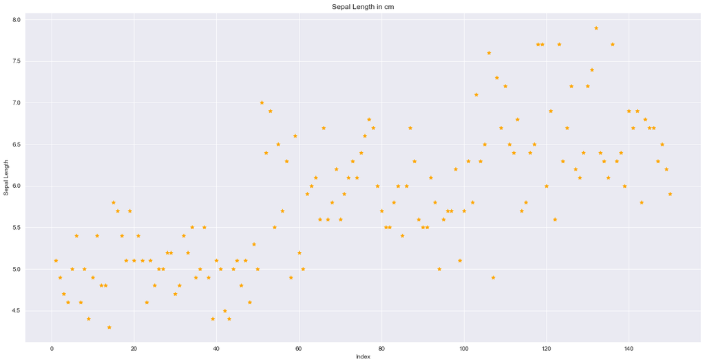

```python
plt.figure(figsize=(20,10))

plt.scatter(iris_df.index, iris_df['sepal length (cm)'], color = colors[4], marker='*')
plt.title('Sepal Length in cm')
plt.xlabel('Index')
plt.ylabel('Sepal Length')

plt.show()
```

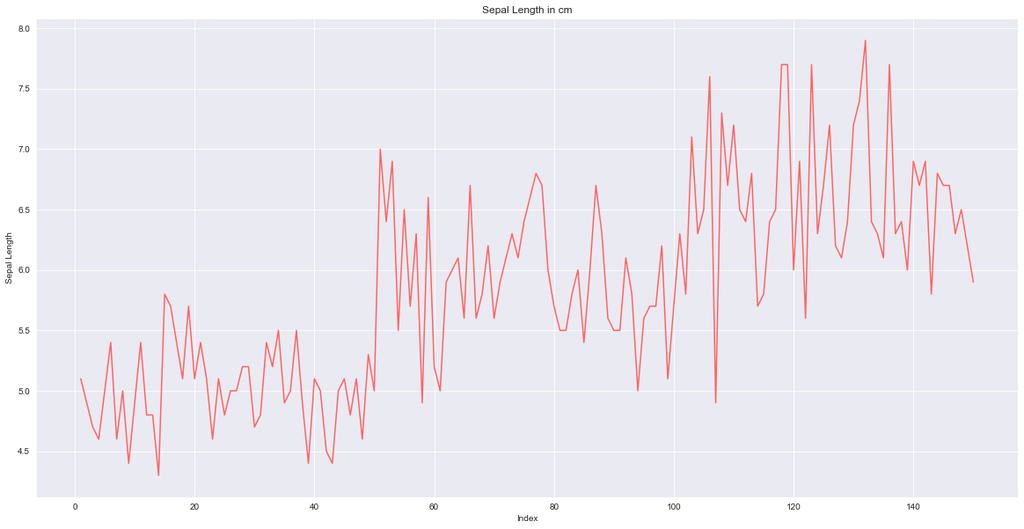

```python
plt.figure(figsize=(20,10))

plt.plot(iris_df.index, iris_df['sepal length (cm)'], color = colors[3])
plt.title('Sepal Length in cm')
plt.xlabel('Index')
plt.ylabel('Sepal Length')

plt.show()
```

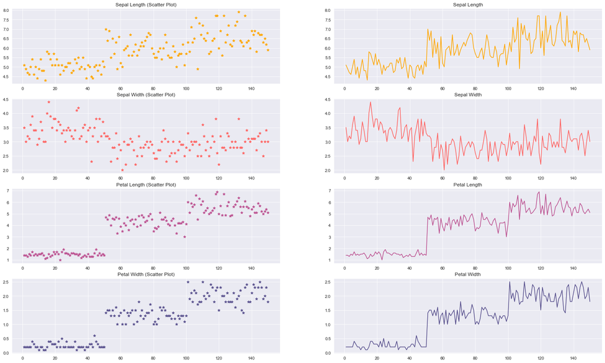

```python
plt.figure(figsize=(20,10))

fig, ax = plt.subplots(4, 2, figsize=(25,15))

ax[0,0].scatter(iris_df.index, iris_df['sepal length (cm)'], color=colors[4], marker='*')
ax[0,0].set_title('Sepal Length (Scatter Plot)')

ax[0,1].plot(iris_df.index, iris_df['sepal length (cm)'], color=colors[4])
ax[0,1].set_title('Sepal Length')

ax[1,0].scatter(iris_df.index, iris_df['sepal width (cm)'], color=colors[3], marker='*')
ax[1,0].set_title('Sepal Width (Scatter Plot)')

ax[1,1].plot(iris_df.index, iris_df['sepal width (cm)'], color=colors[3])
ax[1,1].set_title('Sepal Width')

ax[2,0].scatter(iris_df.index, iris_df['petal length (cm)'], color=colors[2], marker='*')
ax[2,0].set_title('Petal Length (Scatter Plot)')

ax[2,1].plot(iris_df.index, iris_df['petal length (cm)'], color=colors[2])
ax[2,1].set_title('Petal Length')

ax[3,0].scatter(iris_df.index, iris_df['petal width (cm)'], color=colors[1], marker='*')
ax[3,0].set_title('Petal Width (Scatter Plot)')

ax[3,1].plot(iris_df.index, iris_df['petal width (cm)'], color=colors[1])
ax[3,1].set_title('Petal Width')

plt.show()
```

```python
iris_df.sample(n=10)
```

|  | sepal length (cm) | sepal width (cm) | petal length (cm) | petal width (cm) | species | flower name |
| --- | --- | --- | --- | --- | --- | --- |
| 91 | 5.5 | 2.6 | 4.4 | 1.2 | 1 | versicolor |
| 7 | 4.6 | 3.4 | 1.4 | 0.3 | 0 | setosa |
| 72 | 6.1 | 2.8 | 4.0 | 1.3 | 1 | versicolor |
| 106 | 7.6 | 3.0 | 6.6 | 2.1 | 2 | virginica |
| 146 | 6.7 | 3.0 | 5.2 | 2.3 | 2 | virginica |
| 62 | 5.9 | 3.0 | 4.2 | 1.5 | 1 | versicolor |
| 46 | 4.8 | 3.0 | 1.4 | 0.3 | 0 | setosa |
| 29 | 5.2 | 3.4 | 1.4 | 0.2 | 0 | setosa |
| 80 | 5.7 | 2.6 | 3.5 | 1.0 | 1 | versicolor |
| 87 | 6.7 | 3.1 | 4.7 | 1.5 | 1 | versicolor |

### Let's now train our first model!!!

```python
# First import the required tools

from sklearn.model_selection import train_test_split    # Since our data is sufficiently big we will use some of its part to test our model, this data will be new and will not be used in training.
from sklearn.neighbors import KNeighborsClassifier      # As this is a classification problem we will classifier not regressor
```

```python
X = iris_df.drop(['species', 'flower name'], axis=1)
y = iris_df.species

print(f'Example Data : \n{X}\n-----------\nLabels : \n{y}')
```

```
Example Data :
     sepal length (cm)  sepal width (cm)  petal length (cm)  petal width (cm)
1                  5.1               3.5                1.4               0.2
2                  4.9               3.0                1.4               0.2
3                  4.7               3.2                1.3               0.2
4                  4.6               3.1                1.5               0.2
5                  5.0               3.6                1.4               0.2
..                 ...               ...                ...               ...
146                6.7               3.0                5.2               2.3
147                6.3               2.5                5.0               1.9
148                6.5               3.0                5.2               2.0
149                6.2               3.4                5.4               2.3
150                5.9               3.0                5.1               1.8

[150 rows x 4 columns]
-----------
Labels :
1      0
2      0
3      0
4      0
5      0
      ..
146    2
147    2
148    2
149    2
150    2
Name: species, Length: 150, dtype: int32
```

```python
# We will now split the data in training and testing part, training data will be used to train the model and testing data will be absolutely hidden to the model and will be used to test our model's prediction.

X_train, X_test, y_train, y_test = train_test_split(X, y, test_size=0.25, random_state=0)   # test_size=0.25 attribute tells the function to take out 25% of the data for testing it can have any value from 0.01 to 0.99
```

```python
knn = KNeighborsClassifier(n_neighbors=3)   # n_neighbors assigns the value of `k`

knn.fit(X_train, y_train)    # Let us now fit the data and train our model
```

```
KNeighborsClassifier(n_neighbors=3)
```

```python
# Let us now test the accuracy of the model for 3 neighbors

knn.score(X_test, y_test) * 100
```

```
97.36842105263158
```

```python
iris_df.sample()
```

|  | sepal length (cm) | sepal width (cm) | petal length (cm) | petal width (cm) | species | flower name |
| --- | --- | --- | --- | --- | --- | --- |
| 96 | 5.7 | 3.0 | 4.2 | 1.2 | 1 | versicolor |

```python
# Now let us manually test the model with a unique data

y_prediction = knn.predict([[5.6321, 3.1232, 4.3399, 1.23423]])  # Instead of this value (which was taken while curating this course), we will take a value similar to the sample above.

print(f"Predicted species code : {y_prediction[0]}\nPredicted species name : {iris.target_names[y_prediction[0]]}")
```

```
Predicted species code : 1
Predicted species name : versicolor
```

```python
# There is another way to compute the accuracy of our model
from sklearn.metrics import accuracy_score

y_prediction = knn.predict(X_test)
accuracy_score(y_test, y_prediction)*100
```

```
97.36842105263158
```

#### For a different value of neighbors let us train and test our model

```python
knn = KNeighborsClassifier(n_neighbors=int(math.sqrt(150)))   # n_neighbors assigns the value of `k`
# We must take the recommended value, ie. sqrt(150)

knn.fit(X_train, y_train)    # Let us now fit the data and train our model
```

```
KNeighborsClassifier(n_neighbors=12)
```

```python
# Let us now test the accuracy of the model for 12 neighbors

knn.score(X_test, y_test) * 100
```

```
97.36842105263158
```

## 🎉🎉🎉 Congratulations!!! 🎉🎉🎉

## You Just Created Your Own Machine Learning Model!!!